# R Notebook

```r
library(tidyverse)
library(lubridate)
```

1. Load in the code_clan_tweets.csv. Find the number of rows, columns, and lists of all the variable names.

```r
code_clan_tweet <- read_csv("data/code_clan_tweets.csv")
```

```r
dim(code_clan_tweet)
```

```
[1] 234  27
```

```r
names(code_clan_tweet)
```

```
 [1] "tweet_id"               "user_id"
 [3] "created_at"             "screen_name"
 [5] "text"                   "source"
 [7] "display_text_width"     "reply_to_status_id"
 [9] "reply_to_user_id"       "reply_to_screen_name"
[11] "is_quote"               "is_retweet"
[13] "favorite_count"         "retweet_count"
[15] "quote_count"            "reply_count"
[17] "hashtags"               "symbols"
[19] "urls_url"               "urls_t.co"
[21] "urls_expanded_url"      "media_type"
[23] "retweet_source"         "retweet_favorite_count"
[25] "retweet_retweet_count"  "retweet_user_id"
[27] "retweet_location"
```

```r
head(code_clan_tweet)
```

| tweet_id | user_id | created_at | screen_name | text | source | display_text_width | reply_to_status_id | reply_to_user_id | reply_to_screen_name | is_quote | is_retweet | favorite_count | retweet_count | quote_count | reply_count | hashtags | symbols | urls_url | urls_t.co | urls_expanded_url | media_type | retweet_source | retweet_favorite_count | retweet_retweet_count | retweet_user_id | retweet_location |
| --- | --- | --- | --- | --- | --- | --- | --- | --- | --- | --- | --- | --- | --- | --- | --- | --- | --- | --- | --- | --- | --- | --- | --- | --- | --- | --- |
| 347 | 3250721351 | 23/05/19 08:32 | CodeClanScot | @CodeClanScot has arrived in the Highlands! https://t.co/IJT6zbhEBT via @YouTube | Twitter Web App | 100 | NA | NA | NA | FALSE | TRUE | 0 | 1 | NA | NA | NA | NA | youtu.be/r3970XRMgeg | https://t.co/IJT6zbhEBT | https://youtu.be/r3970XRMgeg | NA | Twitter for iPhone | 5 | 1 | 1.110000e+18 | Edinburgh, Scotland |
| 346 | 3250721351 | 22/05/19 14:04 | CodeClanScot | We talked to one of our grads, Alex, about what it was like coming to CodeClan and changing career ___ Read her story here: https://t.co/UuFLgOFmcB | Twitter Web App | 148 | NA | NA | NA | FALSE | FALSE | 5 | 1 | NA | NA | NA | NA | bit.ly/2Hw8T1e | https://t.co/UuFLgOFmcB | https://bit.ly/2Hw8T1e | NA | NA | NA | NA | NA | NA |
| 345 | 3250721351 | 22/05/19 14:01 | CodeClanScot | A week to go until our #Dundee Sourcing the Next Generation of Talent event - have you booked your place yet? Come along to hear from @eplacementscot @GA_Dundee @CodeClanScot and @OUScotland on how th… | Twitter Web App | 140 | NA | NA | NA | FALSE | TRUE | 0 | 5 | NA | NA | Dundee | NA | NA | NA | NA | NA | Hootsuite Inc. | 6 | 5 | 3.997880e+07 | Scotland |
| 344 | 3250721351 | 22/05/19 13:22 | CodeClanScot | New #tech means new business opportunities. Join @IngledewStephen, @C_Leaver, @MaMChannel, @GerryMcCusker, @DonaldMcL, @pollyp + more at #DigitalScotland19 for some exciting chats around #skills &amp;… | Twitter Web App | 140 | NA | NA | NA | FALSE | TRUE | 0 | 4 | NA | NA | tech | NA | NA | NA | NA | NA | Twitter Web Client | 6 | 4 | 3.288078e+09 | Edinburgh, Scotland |
| 343 | 3250721351 | 22/05/19 10:10 | CodeClanScot | Scotland needs Data Analysts! Learn how you can gain the skills to transform your career at our Data Analysis Information Evening this Thursday. book your free ticket here: https://t.co/0UDZFQaGeB htt… | Twitter Web App | 196 | NA | NA | NA | FALSE | FALSE | 3 | 1 | NA | NA | NA | NA | bit.ly/2JUmdy0 | https://t.co/0UDZFQaGeB | http://bit.ly/2JUmdy0 | photo | NA | NA | NA | NA | NA |
| 342 | 3250721351 | 21/05/19 13:16 | CodeClanScot | RT @TechmumsHQ: Congrats to our Edinburgh #techmums on graduating and well done to the amazing @CodeClanScot facilitators for running such a brilliant #techmumsClub #digitalskillsmatter #empoweringwom… | Twitter Web App | 140 | NA | NA | NA | FALSE | TRUE | 0 | 3 | NA | NA | techmums | NA | NA | NA | NA | NA | IFTTT | 8 | 3 | 9.439170e+08 | Chicago, IL |

```r
tail(code_clan_tweet)
```

| tweet_id | user_id | created_at | screen_name | text | source | display_text_width | reply_to_status_id | reply_to_user_id | reply_to_screen_name | is_quote | is_retweet | favorite_count | retweet_count | quote_count | reply_count | hashtags | symbols | urls_url | urls_t.co | urls_expanded_url | media_type | retweet_source | retweet_favorite_count | retweet_retweet_count | retweet_user_id | retweet_location |
| --- | --- | --- | --- | --- | --- | --- | --- | --- | --- | --- | --- | --- | --- | --- | --- | --- | --- | --- | --- | --- | --- | --- | --- | --- | --- | --- |
| 119 | 3250721351 | 12/04/19 15:58 | CodeClanScot | Frances Maxwell, React/JS Developer at Skyscanner, came into our Glasgow campus today to tell our students about her experience! We're always looking for new speakers for our Industry Talks. Reach out… | Twitter Web App | 245 | NA | NA | NA | FALSE | FALSE | 7 | 2 | NA | NA | NA | NA | NA | NA | NA | photo | NA | NA | NA | NA | NA |
| 118 | 3250721351 | 12/04/19 11:45 | CodeClanScot | Huge thanks to @SwarmOnline for coming in to speak to our students today! https://t.co/FY4qS8fezU | Twitter for iPhone | 73 | NA | NA | NA | FALSE | FALSE | 3 | 3 | NA | NA | NA | NA | NA | NA | NA | photo | NA | NA | NA | NA | NA |
| 117 | 3250721351 | 11/04/19 15:36 | CodeClanScot | Scotland needs data analysts! Come to an info session this April and find out how our full-time course can launch you into a new career as an analyst, statistician, research analyst, and more. Book yo… | Twitter Web App | 280 | NA | NA | NA | FALSE | FALSE | 0 | 4 | NA | NA | NA | NA | bit.ly/2QuAUaU | https://t.co/LkU5V4xYrq | https://bit.ly/2QuAUaU | photo | NA | NA | NA | NA | NA |
| 116 | 3250721351 | 11/04/19 13:21 | CodeClanScot | Expand your team\xeas knowledge of R and help your business make more efficient decisions through data. Choose any or all of these one-day courses to quickly upskill your team this Spring: https://t.c… | Twitter Web App | 209 | NA | NA | NA | FALSE | FALSE | 1 | 2 | NA | NA | NA | NA | bit.ly/2DownoZ | https://t.co/cs3iuyoAqx | https://bit.ly/2DownoZ | photo | NA | NA | NA | NA | NA |
| 115 | 3250721351 | 10/04/19 17:30 | CodeClanScot | Part of what makes CodeClan what it is, is who we work with. Learn about some of the great charities and organisations we support and how they help bring more people into the world of tech! https://t.… | Hootsuite Inc. | 213 | NA | NA | NA | FALSE | FALSE | 1 | 1 | NA | NA | NA | NA | bit.ly/2U9NSwh | https://t.co/WziU7jYbWU | https://bit.ly/2U9NSwh | photo | NA | NA | NA | NA | NA |
| 114 | 3250721351 | 10/04/19 14:43 | CodeClanScot | Been with the awesome @TheHappyLass at @CodeClanScot today, and we were blown away: such cool people there and an amazing venue for our #WebVR workshops in #Glasgow! Thank you guys for being the offic… | Twitter Web App | 140 | NA | NA | NA | FALSE | TRUE | 0 | 2 | NA | NA | NA | NA | NA | NA | NA | NA | Twitter Web Client | 9 | 2 | 8.67e+17 | Edinburgh, UK |

2. First, we’re going to summarise the number of likes CodeClan tweets have. Create a boxplot to check for outliers.

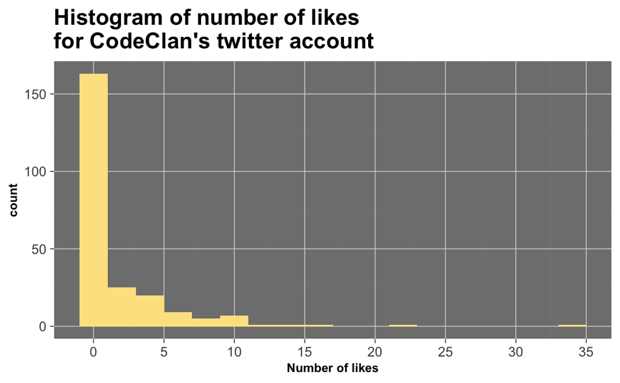

```r
ggplot(code_clan_tweet) +
  aes(x = favorite_count) +
  geom_histogram(fill = "#fee391", binwidth = 2) +
  labs(
    x = "Number of likes",
    title = "Histogram of number of likes\nfor CodeClan's twitter account"
  ) +
  scale_x_continuous(breaks = seq(0, 35, 5)) +
  theme_dark() +
  theme(
    title = element_text(size = 12, face = "bold"),
    axis.title = element_text(size = 8, face = "bold"),
    panel.grid.major = element_line(colour = "grey84"),
    panel.grid.minor = element_line(colour = "grey54")
  )
```

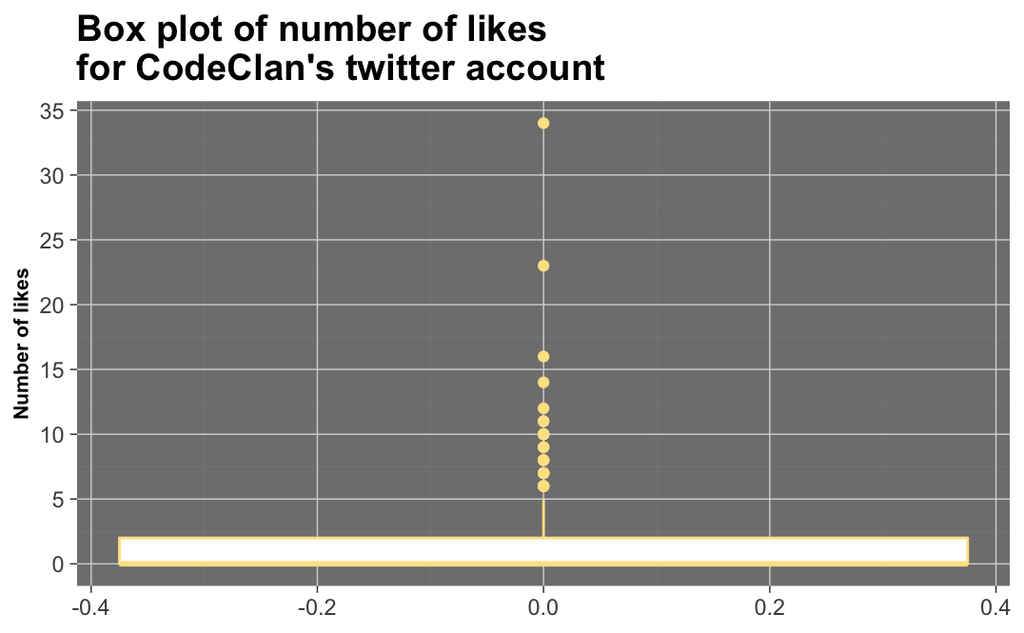

```r
ggplot(code_clan_tweet) +
  aes(y = favorite_count) +
  geom_boxplot(colour = "#fee391") +
  labs(
    y = "Number of likes",
    title = "Box plot of number of likes\nfor CodeClan's twitter account"
  ) +
  scale_y_continuous(breaks = seq(0, 35, 5)) +
  theme_dark() +
  theme(
    title = element_text(size = 12, face = "bold"),
    axis.title = element_text(size = 8, face = "bold"),
    panel.grid.major = element_line(colour = "grey84"),
    panel.grid.minor = element_line(colour = "grey54")
  )
```

3. Summarise the number of likes (stored in favorite_count) that CodeClan tweets have got. Don’t summarise when it was a quoted tweet (is_quote variable).

```r
code_clan_tweet %>%
  filter(is_quote == FALSE) %>%
  summarise(count = n())
```

| count |
| --- |
| 227 |

4. Summarise the mean number of retweets (retweet_count), by the type of platform that was used to tweet (source).

```r
code_clan_tweet %>%
  group_by(source) %>%
  summarise(mean = mean(retweet_count)) %>%
  arrange(desc(mean))
```

| source | mean |
| --- | --- |
| TweetDeck | 5.000000 |
| Tweetbot for Mac | 4.000000 |
| Twitter for iPhone | 2.901235 |
| Twitter Web App | 2.436975 |
| Twitter Web Client | 2.363636 |
| Hootsuite Inc. | 1.428571 |

5. Count the number of likes by media type, and arrange them from most likes to least.

```r
code_clan_tweet %>%
  group_by(media_type) %>%
  summarise(sum = sum(favorite_count)) %>%
  arrange(desc(sum))
```

| media_type | sum |
| --- | --- |
| photo | 371 |
| NA | 75 |

6. Find the mean number of characters a CodeClan tweet contains.

```r
code_clan_tweet %>%
  summarise(mean = mean(display_text_width))
```

| mean |
| --- |
| 149.4188 |

7. Convert the dates in the created_at variable into ISO format, and store them in a new datetime variable. Get the months and store them in a new variable called month.

```r
map(code_clan_tweet$created_at, dmy_hm)

tweet_with_month <- code_clan_tweet %>%
                      mutate(Month = month(created_at))
```

8. Using your new month column, count the number retweets codeclan got in May vs April.

```r
tweet_with_month %>%
  group_by(Month) %>%
  summarise(Count = sum(retweet_count))
```

| Month | Count |
| --- | --- |
| 4 | 288 |
| 5 | 302 |

9. The code_clan_info.csv contains url and tweet info. Load this in, and join it to the code_clan_tweets data, so that you have a tweet url for wherever you have a tweet.

```r
code_clan_info <- read_csv("data/code_clan_info.csv")
```

```r
names(code_clan_info)
```

```
 [1] "tweet_id"           "status_url"         "name"
 [4] "location"           "description"        "url"
 [7] "protected"          "followers_count"    "friends_count"
[10] "listed_count"       "statuses_count"     "favourites_count"
[13] "account_created_at" "verified"           "profile_url"
```

```r
all_tweets <- left_join(tweet_with_month, code_clan_info,
                        by = "tweet_id")
```

10. From your new joined data, create a variable which has all the hashtags in lowercase for analysis.

```r
all_tweets$hashtags <- str_to_lower(all_tweets$hashtags)
```

11. Some tweets have more than one hashtag, denoted by the c() expression at the start of the string. Use the substr and str_detect functions to create a tibble where the first letter of the string begins with a c.

```r
multiple_hashtags_tibble <- all_tweets %>%
  filter(str_detect(hashtags, ".\\(|\\).")) %>%
  mutate(multiple_hashtags = str_sub(hashtags, start = 3, end = -2))
```

12. Use the str_extract function to find all cases where a tweet mentions edinburgh anywhere in it. How many mentions of Edinburgh are there in CodeClan’s tweets? Hint: you may need to make sure your tweets are all the same case before searching.

```r
all_tweets$text <- str_to_lower(all_tweets$text)
ed_pattern <- "edinburgh"
edinburghs <- str_extract_all(all_tweets$text, pattern = ed_pattern)
sum(str_count(all_tweets$text, pattern = ed_pattern))
```

```
[1] 37
```

13. Use str_extract_all with a regular expression to find out which users CodeClan have been tweeting. Hint: think about all the different characters which could be in a username

```r
user_pattern <- "@[a-zA-Z0-9._-]+[a-zA-Z0-9._-]+"
users <- str_extract_all(all_tweets$text, user_pattern)
```

Extensions: Tasks 14. codeclan_info has tweet url (status_url) stored in a string. Save the numeric substring part of the string in a new variable called status_url_number

```r
status_url_number <- str_sub(code_clan_info$status_url,
                             start = -19)
```

15. Use the str_replace function to replace the url numbers in the status_url_number string with a the word HIDDEN_URL

```r
hidden_pattern <- "HIDDEN_URL"
numb_pattern <- "[0-9]{19}"
status_url_hidden <- str_replace_all(status_url_number,
                numb_pattern,
                hidden_pattern)
```

16. Use str_detect to see which tweets don’t include a shortened link (https://t.co/**********)

```r
short_pattern <- "https://t.co/[a-zA-Z0-9]{10}"
str_detect(code_clan_tweet$text,
           pattern = short_pattern,
           negate = TRUE)
```

```
  [1] FALSE FALSE FALSE FALSE FALSE FALSE  TRUE FALSE FALSE FALSE  TRUE
 [12] FALSE FALSE FALSE  TRUE FALSE FALSE FALSE FALSE FALSE FALSE FALSE
 [23] FALSE FALSE FALSE FALSE FALSE FALSE  TRUE FALSE FALSE FALSE FALSE
 [34] FALSE FALSE FALSE FALSE  TRUE FALSE FALSE FALSE FALSE FALSE  TRUE
 [45] FALSE FALSE FALSE FALSE  TRUE FALSE  TRUE FALSE FALSE FALSE FALSE
 [56] FALSE FALSE FALSE FALSE FALSE FALSE FALSE FALSE FALSE  TRUE FALSE
 [67] FALSE FALSE FALSE FALSE  TRUE FALSE FALSE FALSE FALSE  TRUE FALSE
 [78] FALSE FALSE FALSE FALSE  TRUE FALSE FALSE FALSE FALSE FALSE FALSE
 [89] FALSE FALSE FALSE FALSE FALSE FALSE FALSE FALSE FALSE FALSE FALSE
[100] FALSE  TRUE FALSE FALSE FALSE  TRUE FALSE FALSE FALSE FALSE FALSE
[111] FALSE FALSE FALSE  TRUE FALSE FALSE FALSE FALSE FALSE FALSE FALSE
[122] FALSE FALSE FALSE FALSE  TRUE FALSE FALSE  TRUE FALSE FALSE  TRUE
[133] FALSE FALSE FALSE FALSE FALSE FALSE FALSE  TRUE FALSE FALSE FALSE
[144] FALSE FALSE FALSE FALSE FALSE FALSE FALSE FALSE FALSE FALSE FALSE
[155]  TRUE  TRUE FALSE FALSE FALSE  TRUE FALSE FALSE FALSE FALSE FALSE
[166] FALSE FALSE FALSE FALSE FALSE FALSE FALSE FALSE FALSE FALSE FALSE
[177]  TRUE FALSE  TRUE FALSE  TRUE FALSE  TRUE  TRUE FALSE FALSE FALSE
[188] FALSE FALSE FALSE FALSE FALSE FALSE FALSE FALSE FALSE FALSE FALSE
[199] FALSE FALSE FALSE  TRUE FALSE FALSE FALSE FALSE FALSE FALSE FALSE
[210]  TRUE FALSE FALSE FALSE FALSE FALSE FALSE FALSE FALSE FALSE FALSE
[221] FALSE FALSE FALSE  TRUE FALSE FALSE FALSE FALSE FALSE FALSE FALSE
[232] FALSE FALSE FALSE
```